# Retail Sales Analysis in R

The task of the project is to analyze the chips sales and customers’ purchasing behavior. To identify the sales drivers, we are interested in knowing which customer segment spends the most and their purchasing behavior. For example, we want to explore whether they have a preference for a particular brand or pack size.

```r
# load relevant packages
library(data.table)
library(ggplot2)
library(readr)
library(dplyr)
library(stringr)
```

```r
#load data and read it as data table
transaction_data <- data.table(fread("transactions_data.csv"))
customer_data <- data.table(fread("purchase_behaviour.csv"))
```

```r
# check the number of rows and columns in each dataset
dim(transaction_data)
```

```
## [1] 264836      8
```

```r
dim(customer_data)
```

```
## [1] 72637     3
```

```r
# rename columns for easier understanding
# first, change the column names to lowercase
names(transaction_data) <- tolower(names(transaction_data))
names(customer_data) <- tolower(names(customer_data))

# change the 'lylty_card_nbr' to 'customer_id'
names(transaction_data)[3] <- 'customer_id'
names(customer_data)[1] <- 'customer_id'
```

```r
# view the head rows of each dataset
head(transaction_data, 5)
```

```
##        date store_nbr customer_id txn_id prod_nbr
## 1: 10/17/18         1        1000      1        5
## 2:  5/14/19         1        1307    348       66
## 3:  5/20/19         1        1343    383       61
## 4:  8/17/18         2        2373    974       69
## 5:  8/18/18         2        2426   1038      108
##                                   prod_name prod_qty tot_sales
## 1:   Natural Chip        Compny SeaSalt175g        2       6.0
## 2:                 CCs Nacho Cheese    175g        3       6.3
## 3:   Smiths Crinkle Cut  Chips Chicken 170g        2       2.9
## 4:   Smiths Chip Thinly  S/Cream&Onion 175g        5      15.0
## 5: Kettle Tortilla ChpsHny&Jlpno Chili 150g        3      13.8
```

```r
head(customer_data, 5)
```

```
##    customer_id              lifestage premium_customer
## 1:        1000  YOUNG SINGLES/COUPLES          Premium
## 2:        1002  YOUNG SINGLES/COUPLES       Mainstream
## 3:        1003         YOUNG FAMILIES           Budget
## 4:        1004  OLDER SINGLES/COUPLES       Mainstream
## 5:        1005 MIDAGE SINGLES/COUPLES       Mainstream
```

Data Cleaning - Convert the data type if a variable is not correctly formatted - Handle missing values if there is any  
- Handle duplicates if there is any

```r
# use str() to get the data type information about each variable
str(transaction_data)
```

```
## Classes 'data.table' and 'data.frame':   264836 obs. of  8 variables:
##  $ date       : chr  "10/17/18" "5/14/19" "5/20/19" "8/17/18" ...
##  $ store_nbr  : int  1 1 1 2 2 4 4 4 5 7 ...
##  $ customer_id: int  1000 1307 1343 2373 2426 4074 4149 4196 5026 7150 ...
##  $ txn_id     : int  1 348 383 974 1038 2982 3333 3539 4525 6900 ...
##  $ prod_nbr   : int  5 66 61 69 108 57 16 24 42 52 ...
##  $ prod_name  : chr  "Natural Chip        Compny SeaSalt175g" "CCs Nacho Cheese    175g" "Smiths Crinkle Cut  Chips Chicken 170g" "Smiths Chip Thinly  S/Cream&Onion 175g" ...
##  $ prod_qty   : int  2 3 2 5 3 1 1 1 1 2 ...
##  $ tot_sales  : num  6 6.3 2.9 15 13.8 5.1 5.7 3.6 3.9 7.2 ...
##  - attr(*, ".internal.selfref")=<externalptr>
```

The column ‘date’ is not in a date format. Let’s convert it to date type

```r
transaction_data$date <- as.Date(transaction_data$date, format="%m/%d/%y")
```

```r
# check if there is any missing values
lapply(transaction_data, function(x) sum(is.na(x)))
```

```
## $date
## [1] 0
##
## $store_nbr
## [1] 0
##
## $customer_id
## [1] 0
##
## $txn_id
## [1] 0
##
## $prod_nbr
## [1] 0
##
## $prod_name
## [1] 0
##
## $prod_qty
## [1] 0
##
## $tot_sales
## [1] 0
```

```r
# check the number of unique values in each columns in transaction_data table
transaction_data %>% summarize_all(n_distinct)
```

```
##   date store_nbr customer_id txn_id prod_nbr prod_name prod_qty tot_sales
## 1  364       272       72637 263127      114       114        6       112
```

Since we are interested in analyzing chips only, we need to identify chips products by analyzing the product names first. From the output above, there are total 114 unique product names, and each unique product number is associated with a unique product name.

```r
# get the list of unique product names
products <- unique(transaction_data$prod_name)

# the first 10 product names
products[1:10]
```

```
##  [1] "Natural Chip        Compny SeaSalt175g"
##  [2] "CCs Nacho Cheese    175g"
##  [3] "Smiths Crinkle Cut  Chips Chicken 170g"
##  [4] "Smiths Chip Thinly  S/Cream&Onion 175g"
##  [5] "Kettle Tortilla ChpsHny&Jlpno Chili 150g"
##  [6] "Old El Paso Salsa   Dip Tomato Mild 300g"
##  [7] "Smiths Crinkle Chips Salt & Vinegar 330g"
##  [8] "Grain Waves         Sweet Chilli 210g"
##  [9] "Doritos Corn Chip Mexican Jalapeno 150g"
## [10] "Grain Waves Sour    Cream&Chives 210G"
```

We can observe that there is inconsistency in product names. To better identify chip products, we have to clean the names first. For example, remove the symbol ‘&’ and extra whitespace.

```r
# remove the symbol '&' and extra white spaces
transaction_data[, prod_name := gsub("&", " ", prod_name)][, prod_name := gsub("\\s{2,}", " ", prod_name)]
```

Now, we want to summarize the words in the unique product names and examine these words.

```r
products <- unique(transaction_data$prod_name)

# remove digits from product names
for (i in (1:length(products))){
  # remove digits from product name
  products[i] <- gsub("[0-9]+[a-zA-Z]", "", products[i])
  products[i] <- trimws(products[i], which = "both")
}

# after digits are removed, we can break down each unique product names into individual words
product_words <- data.table(unique(unlist(strsplit(products, " "))))
colnames(product_words) <- 'words'

product_words
```

```
##          words
##   1:   Natural
##   2:      Chip
##   3:    Compny
##   4:   SeaSalt
##   5:       CCs
##  ---
## 193:       Rst
## 194:      Pork
## 195:     Belly
## 196:        Pc
## 197: Bolognese
```

```r
# upon reviewing all of the unique product names, we discovered the word 'salsa', which refers to a variety of sauces. As our analysis is solely focused on chips, we need to exclude it from further examination.
salsa_dt <- transaction_data[grepl("Salsa", transaction_data$prod_name), ]
salsa_dt
```

```
##              date store_nbr customer_id txn_id prod_nbr
##     1: 2019-05-19         4        4074   2982       57
##     2: 2019-05-15        39       39144  35506       57
##     3: 2019-05-20        45       45127  41122       64
##     4: 2018-08-18        56       56013  50090       39
##     5: 2019-05-15        82       82480  82047      101
##    ---
## 18090: 2019-04-20       265      265103 263419       59
## 18091: 2019-03-30       265      265111 263428       35
## 18092: 2018-10-28       266      266278 264104       39
## 18093: 2019-01-11       267      267324 264374       41
## 18094: 2019-01-10       269      269222 266382       64
##                                     prod_name prod_qty tot_sales
##     1: Old El Paso Salsa Dip Tomato Mild 300g        1       5.1
##     2: Old El Paso Salsa Dip Tomato Mild 300g        1       5.1
##     3:    Red Rock Deli SR Salsa Mzzrlla 150g        2       5.4
##     4:   Smiths Crinkle Cut Tomato Salsa 150g        1       2.6
##     5:              Doritos Salsa Medium 300g        1       2.6
##    ---
## 18090:  Old El Paso Salsa Dip Tomato Med 300g        1       5.1
## 18091:             Woolworths Mild Salsa 300g        1       1.5
## 18092:   Smiths Crinkle Cut Tomato Salsa 150g        1       2.6
## 18093:                Doritos Salsa Mild 300g        1       2.6
## 18094:    Red Rock Deli SR Salsa Mzzrlla 150g        2       5.4
```

```r
# remove Salsa products from the dataset
transaction_data <- transaction_data[!grepl("Salsa", transaction_data$prod_name), ]
```

```r
# check again and ensure there is no salsa product
transaction_data[grepl("Salsa", transaction_data$prod_name), ]
```

```
## Empty data.table (0 rows and 8 cols): date,store_nbr,customer_id,txn_id,prod_nbr,prod_name...
```

After salsa products are removed, there are 246742 rows remaining and these are all chips sales records.

```r
dim(transaction_data)
```

```
## [1] 246742      8
```

After preliminary data cleaning, we should take a look at descriptive statistics of our data and see if there is data that doesn’t make sense.

```r
summary(transaction_data)
```

```
##       date              store_nbr      customer_id          txn_id
##  Min.   :2018-07-01   Min.   :  1.0   Min.   :   1000   Min.   :      1
##  1st Qu.:2018-09-30   1st Qu.: 70.0   1st Qu.:  70015   1st Qu.:  67569
##  Median :2018-12-30   Median :130.0   Median : 130367   Median : 135183
##  Mean   :2018-12-30   Mean   :135.1   Mean   : 135531   Mean   : 135131
##  3rd Qu.:2019-03-31   3rd Qu.:203.0   3rd Qu.: 203084   3rd Qu.: 202654
##  Max.   :2019-06-30   Max.   :272.0   Max.   :2373711   Max.   :2415841
##     prod_nbr       prod_name            prod_qty         tot_sales
##  Min.   :  1.00   Length:246742      Min.   :  1.000   Min.   :  1.700
##  1st Qu.: 26.00   Class :character   1st Qu.:  2.000   1st Qu.:  5.800
##  Median : 53.00   Mode  :character   Median :  2.000   Median :  7.400
##  Mean   : 56.35                      Mean   :  1.908   Mean   :  7.321
##  3rd Qu.: 87.00                      3rd Qu.:  2.000   3rd Qu.:  8.800
##  Max.   :114.00                      Max.   :200.000   Max.   :650.000
```

```r
# The max product quantity 200 and the max total sales $650 look suspicious. They can be outliers.
# There are two identical transactions by the same customer with customer_id 226000
transaction_data[transaction_data[, prod_qty == 200], ]
```

```
##          date store_nbr customer_id txn_id prod_nbr
## 1: 2018-08-19       226      226000 226201        4
## 2: 2019-05-20       226      226000 226210        4
##                       prod_name prod_qty tot_sales
## 1: Dorito Corn Chp Supreme 380g      200       650
## 2: Dorito Corn Chp Supreme 380g      200       650
```

```r
# It appears that the customer only makes one purchase per year and bought 200 bags each time.
# We decided to remove the two transactions as they don't look like ordinal retail purchases.
transaction_data <- transaction_data[transaction_data[, prod_qty != 200], ]
```

```r
dim(transaction_data)
```

```
## [1] 246740      8
```

Next, we want to create a column that contains the brand of a product.

```r
# use substr() to extract the product brand from each product name
transaction_data[, brand_name:= toupper(substr(prod_name, 1, regexpr(pattern = " ", prod_name) -1))]

# count the frequency for each brand name and order the count in descending order
transaction_data[, "brand_name"][, .(brands_count = .N), by = .(brand_name)][order (-brands_count)]
```

```
##     brand_name brands_count
##  1:     KETTLE        41288
##  2:     SMITHS        27390
##  3:   PRINGLES        25102
##  4:    DORITOS        22041
##  5:      THINS        14075
##  6:        RRD        11894
##  7:  INFUZIONS        11057
##  8:         WW        10320
##  9:       COBS         9693
## 10:   TOSTITOS         9471
## 11:   TWISTIES         9454
## 12:   TYRRELLS         6442
## 13:      GRAIN         6272
## 14:    NATURAL         6050
## 15:   CHEEZELS         4603
## 16:        CCS         4551
## 17:        RED         4427
## 18:     DORITO         3183
## 19:     INFZNS         3144
## 20:      SMITH         2963
## 21:    CHEETOS         2927
## 22:      SNBTS         1576
## 23:     BURGER         1564
## 24: WOOLWORTHS         1516
## 25:    GRNWVES         1468
## 26:   SUNBITES         1432
## 27:        NCC         1419
## 28:     FRENCH         1418
##     brand_name brands_count
```

Some brand names are duplicates because they belong to the same brand. For example, ‘WW’ and ‘WOOLWORTHS’, ‘SMITH’ and ‘SMITHS’, etc

```r
# create a mapping for the duplicate brand names
mapping <- c(RED = "RRD", SNBTS = "SUNBITES", INFZNS = "INFUZIONS", WW = "WOOLWORTHS",
             SMITH = "SMITHS", NCC = "NATURAL", DORITO = "DORITOS", GRAIN = "GRNWVES")
names(mapping)
```

```
## [1] "RED"    "SNBTS"  "INFZNS" "WW"     "SMITH"  "NCC"    "DORITO" "GRAIN"
```

```r
# combine the duplicate brand names
transaction_data[, brand_name := ifelse(brand_name %in% names(mapping), mapping[brand_name], brand_name)]
```

```r
# The combining resulted in a total of 20 distinct brands.
transaction_data[, "brand_name"][, .(brands_count = .N), by = .(brand_name)][order (-brands_count)]
```

```
##     brand_name brands_count
##  1:     KETTLE        41288
##  2:     SMITHS        30353
##  3:    DORITOS        25224
##  4:   PRINGLES        25102
##  5:        RRD        16321
##  6:  INFUZIONS        14201
##  7:      THINS        14075
##  8: WOOLWORTHS        11836
##  9:       COBS         9693
## 10:   TOSTITOS         9471
## 11:   TWISTIES         9454
## 12:    GRNWVES         7740
## 13:    NATURAL         7469
## 14:   TYRRELLS         6442
## 15:   CHEEZELS         4603
## 16:        CCS         4551
## 17:   SUNBITES         3008
## 18:    CHEETOS         2927
## 19:     BURGER         1564
## 20:     FRENCH         1418
```

Create a column ‘pack_size’ to contain the pack size information of the product.

```r
# get the pack size for each product
transaction_data$pack_size <- parse_number(transaction_data$prod_name)
```

```r
summary(transaction_data$pack_size)
```

```
##    Min. 1st Qu.  Median    Mean 3rd Qu.    Max.
##    70.0   150.0   170.0   175.6   175.0   380.0
```

The pack size ranges from 70g to 380g, which is reasonable. Next we can count the frequency of each pack size and get a sense of which pack size is the most preferred.

```r
count_pack_size <- transaction_data[, "pack_size"][, .(count = .N), by = pack_size]
# order the count in descending order
count_pack_size <- count_pack_size[order (-count)]
count_pack_size
```

```
##     pack_size count
##  1:       175 66390
##  2:       150 40203
##  3:       134 25102
##  4:       110 22387
##  5:       170 19983
##  6:       165 15297
##  7:       330 12540
##  8:       380  6416
##  9:       270  6285
## 10:       210  6272
## 11:       200  4473
## 12:       135  3257
## 13:       250  3169
## 14:        90  3008
## 15:       190  2995
## 16:       160  2970
## 17:       220  1564
## 18:        70  1507
## 19:       180  1468
## 20:       125  1454
```

Now, let’s explore customer_data table

```r
str(customer_data)
```

```
## Classes 'data.table' and 'data.frame':   72637 obs. of  3 variables:
##  $ customer_id     : int  1000 1002 1003 1004 1005 1007 1009 1010 1011 1012 ...
##  $ lifestage       : chr  "YOUNG SINGLES/COUPLES" "YOUNG SINGLES/COUPLES" "YOUNG FAMILIES" "OLDER SINGLES/COUPLES" ...
##  $ premium_customer: chr  "Premium" "Mainstream" "Budget" "Mainstream" ...
##  - attr(*, ".internal.selfref")=<externalptr>
```

```r
# check the number of unique values per column in the customer_data table
customer_data %>% summarize_all(n_distinct)
```

```
##   customer_id lifestage premium_customer
## 1       72637         7                3
```

```r
# check if there is any missing values
lapply(customer_data, function(x) sum(is.na(x)))
```

```
## $customer_id
## [1] 0
##
## $lifestage
## [1] 0
##
## $premium_customer
## [1] 0
```

Let’s see the number of customers grouped by “lifestage”.

```r
# total unique number of customers by lifestage
lifestage_customers_breakdown <- customer_data[, .(tot_cust = uniqueN(customer_id)), by=lifestage][order (-tot_cust)]

# calculate the percentage
lifestage_customers_breakdown %>% mutate(percentage = tot_cust/(sum(tot_cust)))
```

```
##                 lifestage tot_cust percentage
## 1:               RETIREES    14805 0.20382174
## 2:  OLDER SINGLES/COUPLES    14609 0.20112339
## 3:  YOUNG SINGLES/COUPLES    14441 0.19881052
## 4:         OLDER FAMILIES     9780 0.13464212
## 5:         YOUNG FAMILIES     9178 0.12635434
## 6: MIDAGE SINGLES/COUPLES     7275 0.10015557
## 7:           NEW FAMILIES     2549 0.03509231
```

Let’s see the number of customers segmented by “premium_customer”.

```r
# total unique number of customers by premium category: Budget, Mainstream and Premium
premium_customer_breakdown <- customer_data[, .(tot_cust = uniqueN(customer_id)),
                                            by=premium_customer][order (-tot_cust)]

premium_customer_breakdown %>% mutate(percentage = tot_cust/(sum(tot_cust)))
```

```
##    premium_customer tot_cust percentage
## 1:       Mainstream    29245  0.4026185
## 2:           Budget    24470  0.3368807
## 3:          Premium    18922  0.2605008
```

From the outputs, it shows that retirees, older singles/couples and young singles/couples have the highest number of chips consumers. In next step, we will dive deeper into sales performance in each customer segment by comparing sales metrics.

```r
# merge the two tables:  transaction_data and customer_data
data <- merge(transaction_data, customer_data, all.x = TRUE)

# save the cleaned data for later analysis
fwrite(data, "data.csv")
```

In the next steps, we want to perform data analysis on customer segments

some metrics of interest:

- Who spend the most on chips in terms of total sales, describing customers’ purchasing behavior by life stage and premium
- How many customers are in each segment
- How many chips are bought per customer by segment
- What’s the average chip price by customer segment

```r
data <- data.table(fread("data.csv"))
```

```r
head(data, 10)
```

```
##     customer_id       date store_nbr txn_id prod_nbr
##  1:        1000 2018-10-17         1      1        5
##  2:        1002 2018-09-16         1      2       58
##  3:        1003 2019-03-07         1      3       52
##  4:        1003 2019-03-08         1      4      106
##  5:        1004 2018-11-02         1      5       96
##  6:        1005 2018-12-28         1      6       86
##  7:        1007 2018-12-04         1      7       49
##  8:        1007 2018-12-05         1      8       10
##  9:        1009 2018-11-20         1      9       20
## 10:        1010 2018-09-09         1     10       51
##                                    prod_name prod_qty tot_sales brand_name
##  1:          Natural Chip Compny SeaSalt175g        2       6.0    NATURAL
##  2:    Red Rock Deli Chikn Garlic Aioli 150g        1       2.7        RRD
##  3:       Grain Waves Sour Cream Chives 210G        1       3.6    GRNWVES
```

[output cut: 18 more lines]

```r
str(data)
```

```
## Classes 'data.table' and 'data.frame':   246740 obs. of  12 variables:
##  $ customer_id     : int  1000 1002 1003 1003 1004 1005 1007 1007 1009 1010 ...
##  $ date            : IDate, format: "2018-10-17" "2018-09-16" ...
##  $ store_nbr       : int  1 1 1 1 1 1 1 1 1 1 ...
##  $ txn_id          : int  1 2 3 4 5 6 7 8 9 10 ...
##  $ prod_nbr        : int  5 58 52 106 96 86 49 10 20 51 ...
##  $ prod_name       : chr  "Natural Chip Compny SeaSalt175g" "Red Rock Deli Chikn Garlic Aioli 150g" "Grain Waves Sour Cream Chives 210G" "Natural ChipCo Hony Soy Chckn175g" ...
##  $ prod_qty        : int  2 1 1 1 1 1 1 1 1 2 ...
##  $ tot_sales       : num  6 2.7 3.6 3 1.9 2.8 3.8 2.7 5.7 8.8 ...
##  $ brand_name      : chr  "NATURAL" "RRD" "GRNWVES" "NATURAL" ...
##  $ pack_size       : int  175 150 210 175 160 165 110 150 330 170 ...
##  $ lifestage       : chr  "YOUNG SINGLES/COUPLES" "YOUNG SINGLES/COUPLES" "YOUNG FAMILIES" "YOUNG FAMILIES" ...
##  $ premium_customer: chr  "Premium" "Mainstream" "Budget" "Budget" ...
##  - attr(*, ".internal.selfref")=<externalptr>
```

```r
data$date <- as.Date(data$date, format="%m/%d/%y")
```

```r
# descriptive statistics of the dataset
summary(data)
```

```
##   customer_id           date              store_nbr         txn_id
##  Min.   :   1000   Min.   :2018-07-01   Min.   :  1.0   Min.   :      1
##  1st Qu.:  70015   1st Qu.:2018-09-30   1st Qu.: 70.0   1st Qu.:  67569
##  Median : 130367   Median :2018-12-30   Median :130.0   Median : 135182
##  Mean   : 135530   Mean   :2018-12-30   Mean   :135.1   Mean   : 135130
##  3rd Qu.: 203083   3rd Qu.:2019-03-31   3rd Qu.:203.0   3rd Qu.: 202652
##  Max.   :2373711   Max.   :2019-06-30   Max.   :272.0   Max.   :2415841
##     prod_nbr       prod_name            prod_qty       tot_sales
##  Min.   :  1.00   Length:246740      Min.   :1.000   Min.   : 1.700
##  1st Qu.: 26.00   Class :character   1st Qu.:2.000   1st Qu.: 5.800
##  Median : 53.00   Mode  :character   Median :2.000   Median : 7.400
##  Mean   : 56.35                      Mean   :1.906   Mean   : 7.316
##  3rd Qu.: 87.00                      3rd Qu.:2.000   3rd Qu.: 8.800
##  Max.   :114.00                      Max.   :5.000   Max.   :29.500
##   brand_name          pack_size      lifestage         premium_customer
##  Length:246740      Min.   : 70.0   Length:246740      Length:246740
##  Class :character   1st Qu.:150.0   Class :character   Class :character
##  Mode  :character   Median :170.0   Mode  :character   Mode  :character
##                     Mean   :175.6
##                     3rd Qu.:175.0
##                     Max.   :380.0
```

Let’s get an overview of the total sales and total quantity sold over the full observation period.

```r
data1 <- data[, c("date", "tot_sales", "prod_qty")][, date := substring(date, 1, 7)]
data1 <- data1[, .(sales = sum(tot_sales), tot_qty_sold = sum(prod_qty)), by = date][order (date)]
```

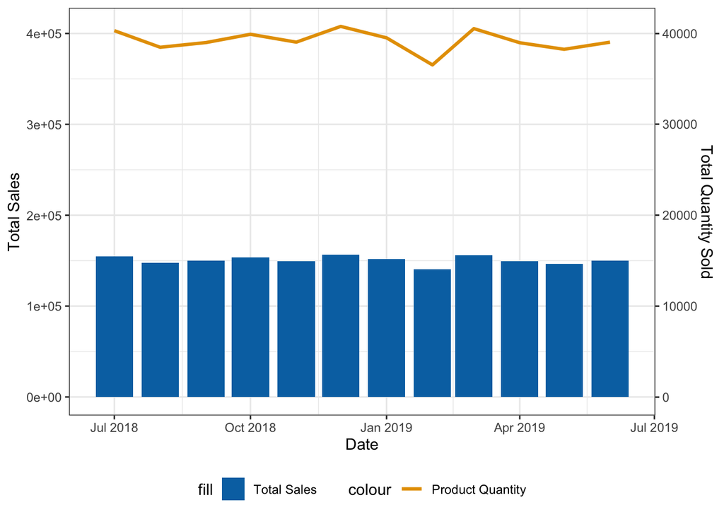

```r
data1$date <- as.Date(paste0(data1$date, "-01"), format = "%Y-%m-%d")

ggplot(data1, aes(x = date)) +
  geom_bar(aes(y = sales, fill = "Total Sales"), stat = "identity") +
  geom_line(aes(y = tot_qty_sold * 10, color = "Product Quantity"), size=1.1, yaxis = "right") +
  scale_y_continuous(
    name = "Total Sales",
    sec.axis = sec_axis(~./10, name = "Total Quantity Sold")
  ) +
  labs(x = "Date") +
  theme_bw() +
  theme(legend.position = "bottom") +
  scale_fill_manual(values = c("#0072B2")) +
  scale_color_manual(values = c("#E69F00"))
```

To begin with, we group the data by ‘lifestage’ and ‘premium_customer’ and calculate these metrics: - total sales - total quantity sold - total number of unique customers - and the number of quantity sold per customer

```r
sales_by_segment <- data[, .(sales = sum(tot_sales), tot_cust = uniqueN(customer_id),
                             tot_qty = sum(prod_qty),
                             num_qty_sold_per_cust = sum(prod_qty)/uniqueN(customer_id),
                             avg_price_unit = sum(tot_sales)/ sum(prod_qty)),
                         by = .(lifestage, premium_customer)][order (-sales)]

sales_by_segment
```

```
##                  lifestage premium_customer     sales tot_cust tot_qty
##  1:         OLDER FAMILIES           Budget 156863.75     4611   41853
##  2:  YOUNG SINGLES/COUPLES       Mainstream 147582.20     7917   36225
##  3:               RETIREES       Mainstream 145168.95     6358   37677
##  4:         YOUNG FAMILIES           Budget 129717.95     3953   34482
##  5:  OLDER SINGLES/COUPLES           Budget 127833.60     4849   32883
##  6:  OLDER SINGLES/COUPLES       Mainstream 124648.50     4858   32607
##  7:  OLDER SINGLES/COUPLES          Premium 123537.55     4682   31695
##  8:               RETIREES           Budget 105916.30     4385   26932
##  9:         OLDER FAMILIES       Mainstream  96413.55     2788   25804
## 10:               RETIREES          Premium  91296.65     3812   23266
## 11:         YOUNG FAMILIES       Mainstream  86338.25     2685   23194
## 12: MIDAGE SINGLES/COUPLES       Mainstream  84734.25     3298   21213
## 13:         YOUNG FAMILIES          Premium  78571.70     2398   20901
## 14:         OLDER FAMILIES          Premium  75242.60     2231   20239
```

[output cut: 31 more lines]

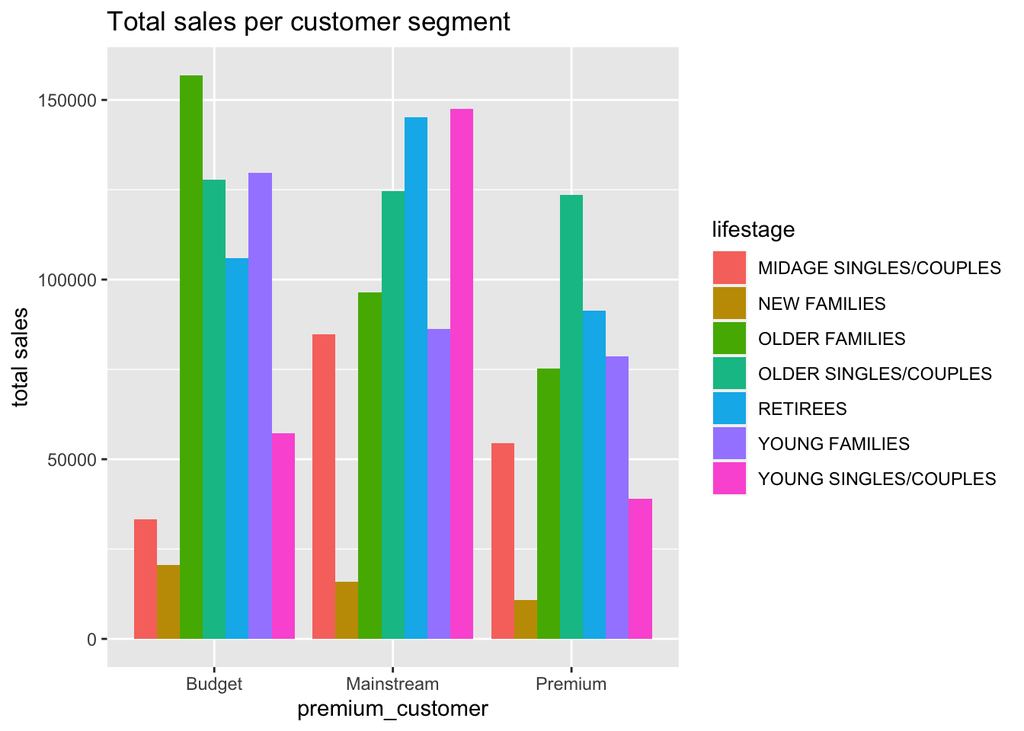

```r
# visualize the total sales per customer segment
ggplot(sales_by_segment, aes(x = premium_customer, y = sales, fill = factor(lifestage))) +
  geom_bar(stat= "identity", position = "dodge") +
  labs(title = "Total sales per customer segment",
       x = "premium_customer",
       y = "total sales",
       fill = "lifestage")
```

Observations: From the count plots above, it is apparent that older families in the budget category contribute the most to chips sales and the second largest sales comes from mainstream young singles/couples. And retirees of mainstream segment consumers are the third largest sales group.

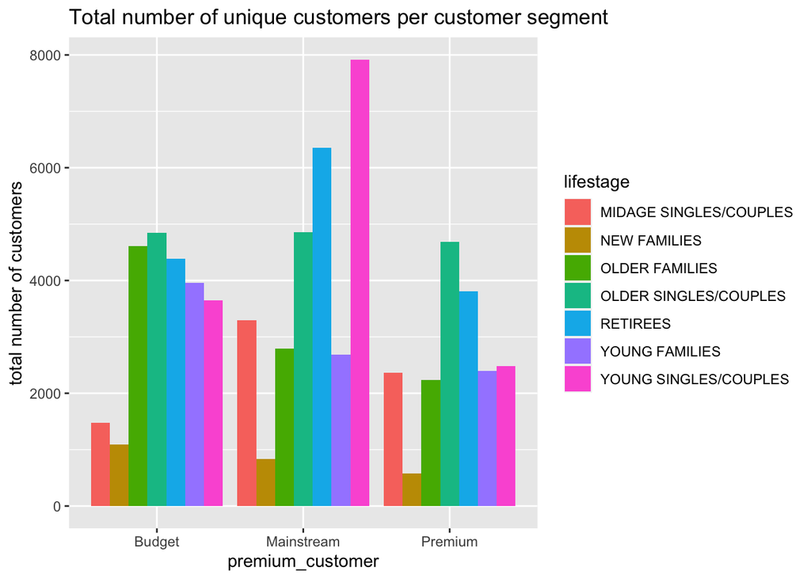

```r
# visualize the total number of unique of customers in each segment
ggplot(sales_by_segment, aes(x = premium_customer, y = tot_cust, fill = factor(lifestage))) +
  geom_bar(stat= "identity", position = "dodge") +
  labs(title = "Total number of unique customers per customer segment",
       x = "premium_customer",
       y = "total number of customers",
       fill = "lifestage")
```

Let’s explore their purchasing behavior: for example, if they have a preference for a brand or pack size.

```r
# filter the sales data from this customer segment
segment <- subset(data, lifestage == "YOUNG SINGLES/COUPLES" & premium_customer == "Mainstream" )

others <- data[!(lifestage == "YOUNG SINGLES/COUPLES" & premium_customer == "Mainstream"), ]
```

```r
# use table() to find the frequency of each brand in mainstream young singles/couples customer segment
segment_brand_counts <- data.table(table(segment$brand_name))

# rename columns
names(segment_brand_counts) <- c("brand_name", "count1")

# calculate the percentage of each brad count
segment_brand_counts[, percentage_segment := count1/(sum(count1))]

# top 10 brands preferred by mainstream young singles/couples
top10_brand_counts_segment <- segment_brand_counts[order (-count1)][1:10, ]

top10_brand_counts_segment
```

```
##     brand_name count1 percentage_segment
##  1:     KETTLE   3844         0.19668440
##  2:    DORITOS   2379         0.12172534
##  3:   PRINGLES   2315         0.11845068
##  4:     SMITHS   1921         0.09829104
##  5:  INFUZIONS   1250         0.06395825
##  6:      THINS   1166         0.05966025
##  7:   TWISTIES    900         0.04604994
##  8:   TOSTITOS    890         0.04553827
##  9:        RRD    875         0.04477077
## 10:       COBS    864         0.04420794
```

```r
segment_brand_counts
```

```
##     brand_name count1 percentage_segment
##  1:     BURGER     62        0.003172329
##  2:        CCS    222        0.011358985
##  3:    CHEETOS    166        0.008493655
##  4:   CHEEZELS    346        0.017703643
##  5:       COBS    864        0.044207941
##  6:    DORITOS   2379        0.121725338
##  7:     FRENCH     78        0.003990995
##  8:    GRNWVES    646        0.033053623
##  9:  INFUZIONS   1250        0.063958248
## 10:     KETTLE   3844        0.196684404
## 11:    NATURAL    394        0.020159640
## 12:   PRINGLES   2315        0.118450675
## 13:        RRD    875        0.044770774
## 14:     SMITHS   1921        0.098291036
## 15:   SUNBITES    128        0.006549325
## 16:      THINS   1166        0.059660254
## 17:   TOSTITOS    890        0.045538273
## 18:   TWISTIES    900        0.046049939
## 19:   TYRRELLS    619        0.031672124
## 20: WOOLWORTHS    479        0.024508801
```

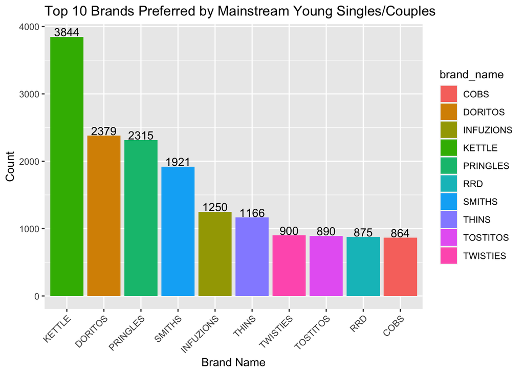

```r
# visualize the count plot for top10 brands liked by the mainstream young singles/couples

ggplot(top10_brand_counts_segment, aes(x = reorder(brand_name, -count1), y = count1, fill = brand_name)) +
  geom_bar(stat = "identity") +
  geom_text(aes(label = count1), vjust = -0.1) +
  xlab("Brand Name") +
  ylab("Count") +
  ggtitle("Top 10 Brands Preferred by Mainstream Young Singles/Couples") +
  theme(axis.text.x = element_text(angle = 45, hjust = 1))
```

```r
others_brand_counts <- data.table(table(others$brand_name))

names(others_brand_counts) <- c("brand_name", "count2")

others_brand_counts[, percentage_other := count2/sum(count2)]
others_brand_counts
```

```
##     brand_name count2 percentage_other
##  1:     BURGER   1502      0.006611032
##  2:        CCS   4329      0.019054033
##  3:    CHEETOS   2761      0.012152503
##  4:   CHEEZELS   4257      0.018737126
##  5:       COBS   8829      0.038860719
##  6:    DORITOS  22845      0.100551946
##  7:     FRENCH   1340      0.005897991
##  8:    GRNWVES   7094      0.031224141
##  9:  INFUZIONS  12951      0.057003644
## 10:     KETTLE  37444      0.164809240
## 11:    NATURAL   7075      0.031140513
## 12:   PRINGLES  22787      0.100296660
## 13:        RRD  15446      0.067985352
## 14:     SMITHS  28432      0.125143048
## 15:   SUNBITES   2880      0.012676280
## 16:      THINS  12909      0.056818782
## 17:   TOSTITOS   8581      0.037769151
## 18:   TWISTIES   8554      0.037650311
## 19:   TYRRELLS   5823      0.025629853
## 20: WOOLWORTHS  11357      0.049987676
```

```r
# top 10 brands by others segments other than mainstream young singles/couples
top10_brand_counts_others <- others_brand_counts[order (-count2)][1:10, ]

top10_brand_counts_others
```

```
##     brand_name count2 percentage_other
##  1:     KETTLE  37444       0.16480924
##  2:     SMITHS  28432       0.12514305
##  3:    DORITOS  22845       0.10055195
##  4:   PRINGLES  22787       0.10029666
##  5:        RRD  15446       0.06798535
##  6:  INFUZIONS  12951       0.05700364
##  7:      THINS  12909       0.05681878
##  8: WOOLWORTHS  11357       0.04998768
##  9:       COBS   8829       0.03886072
## 10:   TOSTITOS   8581       0.03776915
```

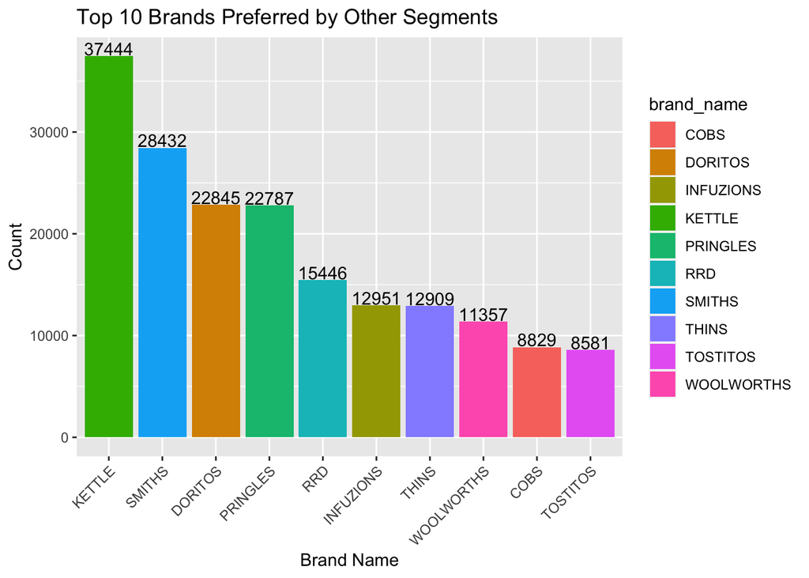

```r
# visualize the count plot for top10 brands in the segment other than mainstream singles/couples
ggplot(top10_brand_counts_others, aes(x = reorder(brand_name, -count2), y = count2, fill = brand_name)) +
  geom_bar(stat = "identity") +
  geom_text(aes(label = count2), vjust = -0.1) +
  xlab("Brand Name") +
  ylab("Count") +
  ggtitle("Top 10 Brands Preferred by Other Segments") +
  theme(axis.text.x = element_text(angle = 45, hjust = 1))
```

```r
brand_counts <- merge(segment_brand_counts, others_brand_counts, by="brand_name")[order (-count1, -count2)]
brand_counts
```

```
##     brand_name count1 percentage_segment count2 percentage_other
##  1:     KETTLE   3844        0.196684404  37444      0.164809240
##  2:    DORITOS   2379        0.121725338  22845      0.100551946
##  3:   PRINGLES   2315        0.118450675  22787      0.100296660
##  4:     SMITHS   1921        0.098291036  28432      0.125143048
##  5:  INFUZIONS   1250        0.063958248  12951      0.057003644
##  6:      THINS   1166        0.059660254  12909      0.056818782
##  7:   TWISTIES    900        0.046049939   8554      0.037650311
##  8:   TOSTITOS    890        0.045538273   8581      0.037769151
##  9:        RRD    875        0.044770774  15446      0.067985352
## 10:       COBS    864        0.044207941   8829      0.038860719
## 11:    GRNWVES    646        0.033053623   7094      0.031224141
## 12:   TYRRELLS    619        0.031672124   5823      0.025629853
## 13: WOOLWORTHS    479        0.024508801  11357      0.049987676
## 14:    NATURAL    394        0.020159640   7075      0.031140513
## 15:   CHEEZELS    346        0.017703643   4257      0.018737126
## 16:        CCS    222        0.011358985   4329      0.019054033
## 17:    CHEETOS    166        0.008493655   2761      0.012152503
## 18:   SUNBITES    128        0.006549325   2880      0.012676280
## 19:     FRENCH     78        0.003990995   1340      0.005897991
## 20:     BURGER     62        0.003172329   1502      0.006611032
```

```r
top4_brands <- c("KETTLE", "DORITOS", "SMITHS", "PRINGLES")

top4 <- data[data[, brand_name %in% top4_brands], ][, c("brand_name", "pack_size", "tot_sales", "prod_qty")]
top4 <- top4[, .(tot_qty_sold = sum(prod_qty), avg_unit_price = sum(tot_sales)/sum(prod_qty)), by=.(brand_name, pack_size)][order (pack_size)]

top4
```

```
##     brand_name pack_size tot_qty_sold avg_unit_price
##  1:   PRINGLES       134        48019       3.699692
##  2:     KETTLE       135         6212       4.200000
##  3:     KETTLE       150        36414       4.599368
##  4:    DORITOS       150        12211       3.900000
##  5:     SMITHS       150        11170       2.600000
##  6:    DORITOS       170        24153       4.399636
##  7:     SMITHS       170        13935       2.899792
##  8:     SMITHS       175        14189       3.000000
##  9:     KETTLE       175        36425       5.399259
## 10:    DORITOS       330         5858       5.700000
## 11:     SMITHS       330        12124       5.700000
## 12:     SMITHS       380         6164       5.900000
## 13:    DORITOS       380         6109       6.392536
```

KETTLE is most favorite brand and it sells three pack sizes. The average unit price for the 135g size is $4.2, while 150g sells slightly higher with an average of $4.6. The largest size, 175g sells at average of $5.4.

```r
top4[top4[, brand_name == "KETTLE"], ]
```

```
##    brand_name pack_size tot_qty_sold avg_unit_price
## 1:     KETTLE       135         6212       4.200000
## 2:     KETTLE       150        36414       4.599368
## 3:     KETTLE       175        36425       5.399259
```

Below is the unit price for each pack size sold by “DORITOS”.

```r
top4[top4[, brand_name == "DORITOS"], ]
```

```
##    brand_name pack_size tot_qty_sold avg_unit_price
## 1:    DORITOS       150        12211       3.900000
## 2:    DORITOS       170        24153       4.399636
## 3:    DORITOS       330         5858       5.700000
## 4:    DORITOS       380         6109       6.392536
```

Let’s look at the unit price for each pack size sold by “SMITHS”. They have more options in terms of pack size and are more economical compared to the two brands above for the same size.

```r
top4[top4[, brand_name == "SMITHS"], ]
```

```
##    brand_name pack_size tot_qty_sold avg_unit_price
## 1:     SMITHS       150        11170       2.600000
## 2:     SMITHS       170        13935       2.899792
## 3:     SMITHS       175        14189       3.000000
## 4:     SMITHS       330        12124       5.700000
## 5:     SMITHS       380         6164       5.900000
```

Pringles only sells one size at $3.7.

```r
top4[top4[, brand_name == "PRINGLES"], ]
```

```
##    brand_name pack_size tot_qty_sold avg_unit_price
## 1:   PRINGLES       134        48019       3.699692
```

Analyze the pack size preference and compare the two groups

```r
segment_pack_size_counts <- data.table(table(segment$pack_size))

# rename columns
names(segment_pack_size_counts) <- c("pack_size", "count1")

# calculate the percentage of each brad count
segment_pack_size_counts[, percentage_segment := count1/(sum(count1))]

segment_pack_size_counts[order (-count1)]
```

```
##     pack_size count1 percentage_segment
##  1:       175   4997        0.255679492
##  2:       150   3080        0.157593123
##  3:       134   2315        0.118450675
##  4:       110   2051        0.104942693
##  5:       170   1575        0.080587393
##  6:       330   1195        0.061144085
##  7:       165   1102        0.056385591
##  8:       380    626        0.032030291
##  9:       270    620        0.031723291
## 10:       210    576        0.029471961
## 11:       135    290        0.014838314
## 12:       250    280        0.014326648
## 13:       200    179        0.009158821
## 14:       190    148        0.007572657
## 15:        90    128        0.006549325
## 16:       160    128        0.006549325
## 17:       180     70        0.003581662
## 18:        70     63        0.003223496
## 19:       220     62        0.003172329
## 20:       125     59        0.003018829
```

```r
top10_pack_size_segment <- segment_pack_size_counts[order (-count1)][1:10, ]
top10_pack_size_segment
```

```
##     pack_size count1 percentage_segment
##  1:       175   4997         0.25567949
##  2:       150   3080         0.15759312
##  3:       134   2315         0.11845068
##  4:       110   2051         0.10494269
##  5:       170   1575         0.08058739
##  6:       330   1195         0.06114409
##  7:       165   1102         0.05638559
##  8:       380    626         0.03203029
##  9:       270    620         0.03172329
## 10:       210    576         0.02947196
```

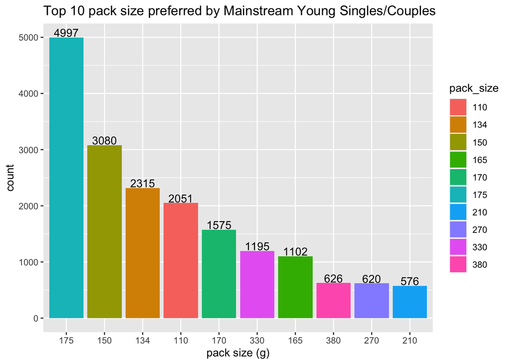

```r
ggplot(top10_pack_size_segment, aes(x = reorder(pack_size, -count1), y = count1, fill = pack_size)) +
  geom_bar(stat = "identity") +
  geom_text(aes(label = count1), vjust = -0.1) +
  xlab("pack size (g)") +
  ylab("count") +
  ggtitle("Top 10 pack size preferred by Mainstream Young Singles/Couples")
```

```r
others_pack_size_counts <- data.table(table(others$pack_size))

# rename columns
names(others_pack_size_counts) <- c("pack_size", "count2")

# calculate the percentage of each brad count
others_pack_size_counts[, percentage_segment := count2/(sum(count2))]

others_pack_size_counts[order (-count2)]
```

```
##     pack_size count2 percentage_segment
##  1:       175  61393        0.270220426
##  2:       150  37123        0.163396363
##  3:       134  22787        0.100296660
##  4:       110  20336        0.089508618
##  5:       170  18408        0.081022553
##  6:       165  14195        0.062479093
##  7:       330  11345        0.049934858
##  8:       380   5790        0.025484604
##  9:       210   5696        0.025070864
## 10:       270   5665        0.024934418
## 11:       200   4294        0.018899981
## 12:       135   2967        0.013059209
## 13:       250   2889        0.012715893
## 14:        90   2880        0.012676280
## 15:       190   2847        0.012531030
## 16:       160   2842        0.012509023
## 17:       220   1502        0.006611032
## 18:        70   1444        0.006355746
## 19:       180   1398        0.006153277
## 20:       125   1395        0.006140073
```

```r
top10_pack_size_others <- others_pack_size_counts[order (-count2)][1:10, ]
top10_pack_size_others
```

```
##     pack_size count2 percentage_segment
##  1:       175  61393         0.27022043
##  2:       150  37123         0.16339636
##  3:       134  22787         0.10029666
##  4:       110  20336         0.08950862
##  5:       170  18408         0.08102255
##  6:       165  14195         0.06247909
##  7:       330  11345         0.04993486
##  8:       380   5790         0.02548460
##  9:       210   5696         0.02507086
## 10:       270   5665         0.02493442
```

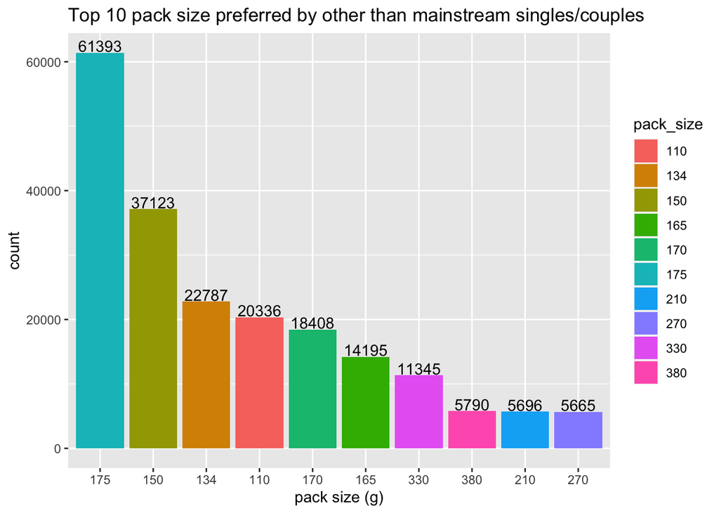

```r
ggplot(top10_pack_size_others, aes(x = reorder(pack_size, -count2), y = count2, fill = pack_size)) +
  geom_bar(stat = "identity") +
  geom_text(aes(label = count2), vjust = -0.1) +
  xlab("pack size (g)") +
  ylab("count") +
  ggtitle("Top 10 pack size preferred by other than mainstream singles/couples")
```

Observations: The 175g pack size is the most popular among all customer segments, and majority of consumers prefer pack sizes in the range of 110g to 175g.

```r
dt <- data[, c("pack_size", "tot_sales")]

# target pack sizes
sizes <- c(110, 125, 134, 135, 150, 160, 165, 170, 175)

dt <- dt[, .(sales = sum(tot_sales)),by = .(pack_size %in% sizes)]

names(dt) <- c("if_less_than_175g", "sales_sum")

# calculate the percentage
dt <- dt %>% mutate(percentage = sales_sum * 100 / sum(sales_sum))
dt
```

```
##    if_less_than_175g sales_sum percentage
## 1:              TRUE   1406045   77.88955
## 2:             FALSE    399133   22.11045
```